# A Usability Analysis of Available R Packages for Text Clustering Methods

Maggie Beiting-Parish, Christopher Runyon

NCME 2022

The document provides the R syntax used to test packages for text clustering methods. Not all packages reviewed in the PowerPoint presentation are included in this document (yet); this document will be continually updated until all package documentation has been included.

# Setup

```r
knitr::opts_chunk$set(echo = TRUE)

# Installing packages; only needs to be done the first time
install.packages(c("BTM", "BullsEyeR", "dplyr", "doc2vec",
                   "keyATM", "lda", "LDAShiny", "LDATS",
                   "ldatuning", "LDAvis", "lsa", "LSAfun",
                   "mallet", "maptpx", "parallel", "purrr",
                   "qdap", "quanteda", "Rlda", "seededlda",
                   "stm", "stmCorrViz", "stmgui", "stminsights",
                   "textmineR", "tidylda", "tidytext", "tm", "tokenizers",
                   "topicdoc", "topicmodels", "TopicScore", "uwot", "dbscan"))
```

## Reading in Data

### Math data

```r
math_items <- read.csv("textclustering_math_items.csv")
save(math_items, file = "math_items.Rdata")
head(math_items, 5)
```

```
##   state year grade domain standard pvalue hasPic
## 1    AK   NA     3   <NA>     <NA>     NA      0
## 2    AK   NA     3   <NA>     <NA>     NA      0
## 3    AK   NA     3   <NA>     <NA>     NA      0
## 4    AK   NA     3   <NA>     <NA>     NA      0
## 5    AK   NA     3   <NA>     <NA>     NA      0
##                                                                                                questionStem
## 1      Mr. Jones bought a rectangular rug that is 7 feet long and 4 feet wide. What is the area of the rug?
## 2         Lisa is solving the division problem 54 /6 . Which number sentence can help Lisa find the answer?
## 3 Mark has all of his books on 6 shelves. Each shelf has 7 books. How many books, in total, does Mark have?
## 4                                                                                           Multiply 4 x 70
## 5                                                          Which number makes the equation true?  ? / 8 = 4
##                a              b              c              d    e
## 1 11 square feet 21 square feet 22 square feet 28 square feet <NA>
## 2    6 + 48 = 42    6 + 54 = 60     6 x 9 = 54   6 x 54 = 324 <NA>
## 3             13             35             42             48 <NA>
## 4             28             74            240            280 <NA>
## 5              2              4             12             32 <NA>
##                                                                                                                                                             completeq
## 1 Mr. Jones bought a rectangular rug that is 7 feet long and 4 feet wide. What is the area of the rug? 11 square feet 21 square feet 22 square feet 28 square feet NA
## 2                Lisa is solving the division problem 54 /6 . Which number sentence can help Lisa find the answer? 6 + 48 = 42 6 + 54 = 60 6 x 9 = 54 6 x 54 = 324 NA
## 3                                            Mark has all of his books on 6 shelves. Each shelf has 7 books. How many books, in total, does Mark have? 13 35 42 48 NA
## 4                                                                                                                                    Multiply 4 x 70 28 74 240 280 NA
## 5                                                                                                       Which number makes the equation true?  ? / 8 = 4 2 4 12 32 NA
##   id
## 1  2
## 2  5
## 3  6
## 4  8
## 5  9
```

### Essay data

```r
essays <- read.csv("textclustering_essays.csv")
head(essays, 5)
```

```
##   essay_id essay_set
## 1     1788         1
## 2     1789         1
## 3     1790         1
## 4     1791         1
## 5     1792         1
##                                                                                                                                                                                                                                                                                                          …
## 1                                                                                                                                                                                                                                                                                                        …
## 2                                                                                                                                                                                                                                                                                                        …
## 3                                                                                                                                                                               Dear Local newspaper, Have you been spending a good portion of your time on computers? Do you think it is effecting you i…
## 4                                                                                                                                                                                                                                                                                                        …
## 5 Dear newspaper, I strongly believe that computers have a positive effect on people. Computers help with education believe it or not. They let people keep in touch with each other no matter where they are. Also computers help people with so many useful things. Education is a very important thing…
##   domain1_predictionid domain2_predictionid
## 1                 1788                   NA
## 2                 1789                   NA
## 3                 1790                   NA
## 4                 1791                   NA
## 5                 1792                   NA
```

```r
# Removing the strings that start with the at sign
essays$essay <- gsub("@\\w+ *", "", essays$essay)
save(essays, file = "essays.Rdata")
```

## Preprocessing data

Many of the packages require that the data be pre-processed and formatted in to a [document-term matrix.](https://en.wikipedia.org/wiki/Document-term_matrix) Not all of the packages that require you to use a document-term matrix have functions available to transform your text into the document-term matrix. Here we have chosen to use functions from the ‘tm’ package to pre-process the data and create the document-term matrix.

```r
# Preprocessing
suppressPackageStartupMessages(library(tm))

# Function to transform the text into a document term matrix (DTM)
# Many of the packages examined require a DTM to perform the
# focal analysis.

makeDTM <- function(text_column){
  focal_text <- VectorSource(text_column)
  focal_text <- VCorpus(focal_text)

  # Need to clean the text; remove whitespace, punctionation, stopwords, etc.

  cleaned_text <- tm_map(focal_text, stripWhitespace)
  cleaned_text <- tm_map(cleaned_text, removePunctuation)
  cleaned_text <- tm_map(cleaned_text, content_transformer(tolower))
  cleaned_text <- tm_map(cleaned_text, removeWords, c(stopwords("en")))
  cleaned_DTM <- DocumentTermMatrix(cleaned_text)
  return(cleaned_DTM)
}


essay_DTM <- makeDTM(essays$essay)
# object.size(essay_DTM) # 6897024 bytes (approx 6.9 MB)
save(essay_DTM, file = "essay_DTM.Rdata")

math_items_DTM <- makeDTM(math_items$completeq)
# object.size(math_items_DTM) # 2280344 bytes (approx 2.3 MB)
save(math_items_DTM, file = "math_items_DTM.Rdata")
```

# ldatuning

Prior to using many of the topic modeling packages, it is necessary to determine how many topics may be present in a given corpus. The ‘ldatuning’ package provides information on how many topics are present by providing several different metrics on the information in a corpus. We strongly recommend consulting the appropriate documentation so you may appropriately evaluate these metrics.

```r
suppressPackageStartupMessages(library(ldatuning))

system.time(
math_tune <- FindTopicsNumber(math_items_DTM,
                              topics = seq(from = 2, to = 20, by = 1),
                              metrics = c("Griffiths2004", "CaoJuan2009",
                                          "Arun2010", "Deveaud2014"),
                              method = "Gibbs",
                              control = list(seed = 420),
                              mc.cores = (parallel::detectCores() / 2),
                              verbose = TRUE))
# user  system elapsed
# 4.04    1.55  183.61
save(math_tune, file = "math_tune.Rdata")

system.time(
essay_tune <- FindTopicsNumber(essay_DTM,
                               topics = seq(from = 2, to = 20, by = 1),
                               metrics = c("Griffiths2004", "CaoJuan2009",
                                           "Arun2010", "Deveaud2014"),
                               method = "Gibbs",
                               control = list(seed = 420),
                               mc.cores = (parallel::detectCores() / 2),
                               verbose = TRUE))
# user  system elapsed
# 5.24    1.33  534.12
save(essay_tune, file = "essay_tune.Rdata")
```

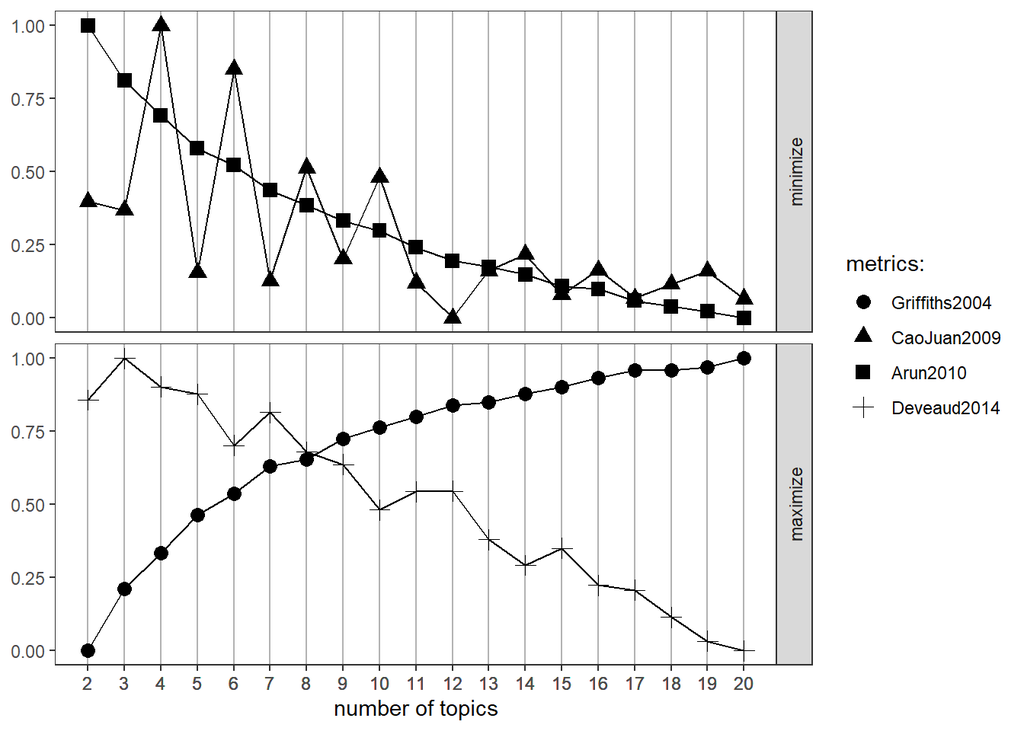

```r
# Number of Topics in Math Items;
# indicates 8 topics are appropriate
FindTopicsNumber_plot(math_tune)
```

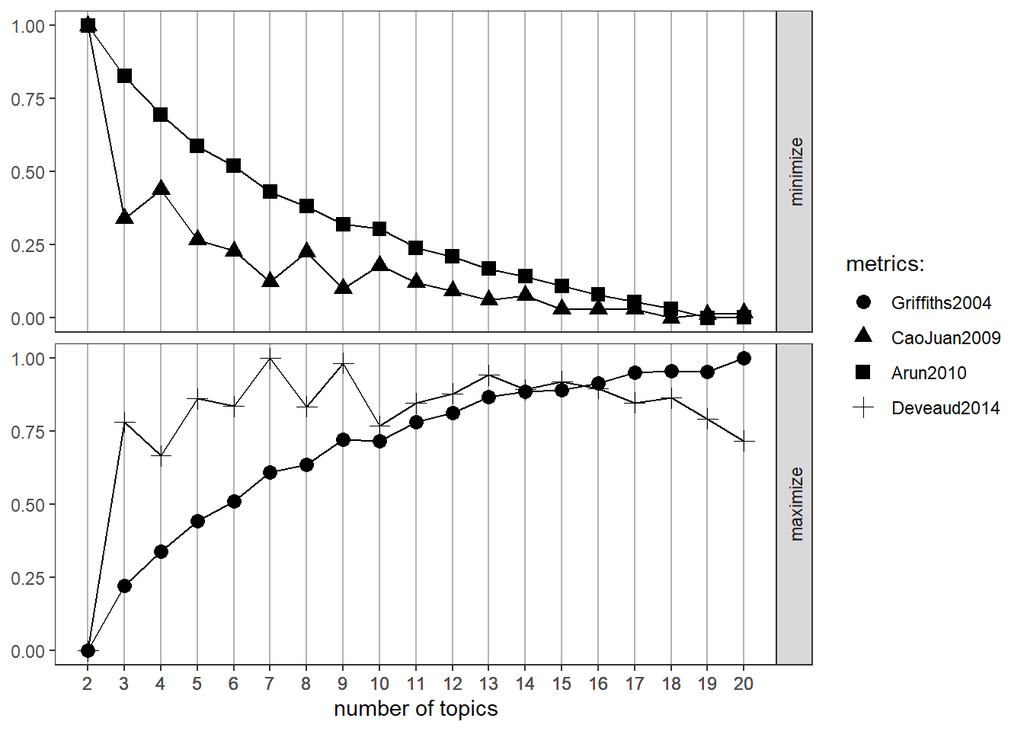

```r
# Number of Topics in Essay Items;
# indicates 14 topics are appropriate
FindTopicsNumber_plot(essay_tune)
```

# BTM

```r
suppressPackageStartupMessages(library(BTM))

# needs data in a tokenized data frame with one row per token with an id column

suppressPackageStartupMessages(library(tokenizers))

# math items
BTM_math_tokendf <- c()

for(i in 1:nrow(math_items)){

  text_vec <- unlist(tokenize_words(math_items$completeq[i]))
  text_vec <- tm::removeWords(text_vec, stopwords("english"))
  text_vec <- text_vec[text_vec != ""]
  rdf <- data.frame(
    id = math_items$id[i],
    word_token = text_vec
  )
  BTM_math_tokendf <- rbind(BTM_math_tokendf, rdf)

}

save(BTM_math_tokendf, file = "BTM_math_tokendf.Rdata")

# essay items
BTM_essay_tokendf <- c()

for(i in 1:nrow(essays)){

  text_vec <- unlist(tokenize_words(essays$essay[i]))
  text_vec <- tm::removeWords(text_vec, stopwords("english"))
  text_vec <- text_vec[text_vec != ""]
  rdf <- data.frame(
    id = essays$essay_id[i],
    word_token = text_vec
  )
  BTM_essay_tokendf <- rbind(BTM_essay_tokendf, rdf)

}

save(BTM_essay_tokendf, file = "BTM_essay_tokendf.Rdata")

## Back to the BTM package
## Running the main analysis and saving those objects

system.time(math_BTM <- BTM(BTM_math_tokendf, k = 8))
#   user  system elapsed
# 508.82    0.10  512.90
object.size(math_BTM) # 1372096 bytes; ~1.4 MB
save(math_BTM, file = "math_BTM.Rdata")

system.time(essay_BTM <- BTM(BTM_essay_tokendf, k = 14))
#    user  system elapsed
# 1953.98    0.38 1962.97
object.size(essay_BTM) # 3823432 bytes; ~3.8 MB
save(essay_BTM, file = "essay_BTM.Rdata")
```

# BullsEyeR

```r
suppressPackageStartupMessages(library(BullsEyeR))

system.time(math_items_bullseye <- BullsEye(math_items$completeq, tno = 8))
   # user  system elapsed
   # 6.89    0.06    6.97
object.size(math_items_bullseye) # 70584 bytes; ~0.07 MB
save(math_items_bullseye, file = "math_items_bullseye.Rdata")

system.time(essay_bullseye <- BullsEye(essays$essay, tno = 14))
  #  user  system elapsed
  # 59.05    0.08   59.25
object.size(essay_bullseye) # 496632 bytes; ~0.5 MB
save(essay_bullseye, file = "essay_bullseye.Rdata")
```

# doc2vec

```r
suppressPackageStartupMessages(library(doc2vec))

# needs either an object returned by paragraph2vec or a data.frame with columns
# ‘doc_id‘and ‘text‘ storing document ids and texts as character vectors or
# a matrix with document embeddings to cluster or a list with elements docs
# and words containing document embeddings to cluster and word embeddings for
# deriving topic summaries

math2vec <- subset(math_items, select = c(id, completeq))
names(math2vec) <- c("doc_id", "text")

essay2vec <- subset(essays, select = c(essay_id, essay))
names(essay2vec) <- c("doc_id", "text")

# Main Analysis
# requires the following packages
suppressPackageStartupMessages(library(uwot))
suppressPackageStartupMessages(library(dbscan))

system.time(math_doc2vec <- top2vec(math2vec))
  #  user  system elapsed
  # 32.72    0.44   32.67
object.size(math_doc2vec) # 13322728 bytes; ~13.3 MB
save(math_doc2vec, file = "math_doc2vec.Rdata")

system.time(essay_doc2vec <- top2vec(essay2vec))
  #  user  system elapsed
  # 73.93    0.19   74.34
object.size(essay_doc2vec) # 15499856 bytes; ~15.5 MB
save(essay_doc2vec, file = "essay_doc2vec.Rdata")
```

# keyATM

```r
suppressPackageStartupMessages(library(keyATM))
suppressPackageStartupMessages(library(quanteda))

# Requires keywords to be used in analysis;
# Will use bag-of-words from the qdap package to
# identify common words just for demonstration

# unusual to use keywords for math items; omitting from demonstration

suppressPackageStartupMessages(library(qdap))

freq_terms(tm::removeWords(essays$essay, stopwords("english")))
# more pre-processing would be beneficial here, but good enough
# for present purposes

essay_keywords <- list(
  machine = c("computer", "computers"),
  paper = c("book", "books"),
  place = "building"
)

essay_dfm <- quanteda::dfm(essays$essay)
essay_docs <- keyATM_read(essay_dfm)

system.time(
essay_keyATM <- keyATM(docs = essay_docs,
                       model = "base",
                       no_keyword_topics = 14,
                       keywords = essay_keywords))
 #   user  system elapsed
 # 478.83    0.43  484.45
object.size(essay_keyATM) # 6823304 bytes; ~6.8 MB
save(essay_keyATM, file = "essay_keyATM.Rdata")
```

# lda

```r
suppressPackageStartupMessages(library(lda))

# Need to first create a document matrix in a different form
# for the lda function to work

# Math Items
math_items_lex <- lexicalize(math_items$completeq, lower = TRUE)

system.time(
math_lda <- lda.collapsed.gibbs.sampler(math_items_lex$documents,
                                        K = 8,
                                        math_items_lex$vocab,
                                        num.iterations = 25,
                                        alpha = 0.1,
                                        eta = 0.1,
                                        compute.log.likelihood = TRUE))
# user  system elapsed
# 1.57    0.00    1.58
object.size(math_lda) # 3674672 bytes; ~3.7 MB
save(math_lda, file = "math_lda.Rdata")

# Essays
essay_lex <- lexicalize(essays$essay, lower = TRUE)

system.time(
essay_lda <- lda.collapsed.gibbs.sampler(essay_lex$documents,
                                         K = 8,
                                         essay_lex$vocab,
                                         num.iterations = 25,
                                         alpha = 0.1,
                                         eta = 0.1,
                                         compute.log.likelihood = TRUE))
# user  system elapsed
#   4.01    0.00    4.04
object.size(essay_lda) # 7872808 bytes; ~7.9 MB
save(essay_lda, file = "essay_lda.Rdata")
```

# LDAShiny

```r
suppressPackageStartupMessages(library(LDAShiny))

# LDAShiny::runLDAShiny()
```

# LDATS

```r
suppressPackageStartupMessages(library(LDATS))

# Math
system.time(
math_LDATS <- LDA_set(as.matrix(math_items_DTM),
                      topics = 8,
                      nseeds = 5)) # more seeds = more time, larger object
# nseeds = 1
#  user  system elapsed
# 49.50    0.56   50.11

# nseeds = 5
#   user  system elapsed
# 267.03    1.39  270.75

# Object size is with 5 seeds; smaller with fewer seeds
object.size(math_LDATS) # 16850232 bytes; ~16.9 MB
save(math_LDATS, file = "math_LDATS.Rdata")

# Essay
system.time(
essay_LDATS <- LDA_set(as.matrix(essay_DTM),
                      topics = 14,
                      nseeds = 5))
# nseeds = 1
#   user  system elapsed
# 391.98    0.88  395.82

# nseeds = 5
#    user  system elapsed
# 2610.19    4.11 2639.20

# Object size is with 5 seeds; smaller with fewer seeds
object.size(essay_LDATS) # 48645112 bytes; ~48.6 MB
save(essay_LDATS, file = "essay_LDATS.Rdata")
```

# lsa

```r
suppressPackageStartupMessages(library(lsa)) # Requires dtm

## Running the main analysis and saving those objects

system.time(lsa_math_result <- lsa(math_items_DTM, 8))
#    user  system elapsed
# 1584.80    1.18 1595.11
object.size(lsa_math_result) # 2092792 bytes; ~2.1 MB
save(lsa_math_result, file = "lsa_math_result.Rdata")

system.time(lsa_essay_result <- lsa(essay_DTM, 14))
#   user  system elapsed
# 1544.13    2.17 1566.45
object.size(lsa_essay_result) # 4902360 bytes; ~4.9 MB
save(lsa_essay_result, file = "lsa_essay_result.Rdata")
```

# LSAfun

```r
suppressPackageStartupMessages(library(LSAfun))

# for use _after_ using the LSA package; from the manual:
# This package is not designed to create LSA semantic spaces.
# In R, this functionality is provided by the package lsa.
```

# seededlda

```r
suppressPackageStartupMessages(library(seededlda))

# Use of this package requires a dataframe of tokens
math_token_df <- math_items %>%
  tidytext::unnest_tokens(word, completeq)
math_dfm <- quanteda::dfm(math_token_df$word)

system.time(
math_seededlda <- textmodel_lda(math_dfm, k = 8))
  #  user  system elapsed
  # 58.72    0.06   59.10
object.size(math_seededlda) # 101271136 bytes; ~101.3 MB
save(math_seededlda, file = "math_seededlda.Rdata")

essay_token_df <- essays %>%
  tidytext::unnest_tokens(word, essay)
essay_dfm <- quanteda::dfm(essay_token_df$word)

system.time(
essay_seededlda <- textmodel_lda(essay_dfm, k = 14))
 #   user  system elapsed
 # 367.33    0.20  368.36
object.size(essay_seededlda) # 398705656 bytes; ~398.7 MB
save(essay_seededlda, file = "essay_seededlda.Rdata")
```

# stm

```r
suppressPackageStartupMessages(library(stm))

# Requires pre-processing via internal (stm) function
math_stm_processed <- textProcessor(math_items$completeq,
                                    metadata = math_items)
save(math_stm_processed, file = "math_stm_processed.Rdata")

essay_stm_processed <- textProcessor(essays$essay,
                                     metadata = essays)
save(essay_stm_processed, file = "essay_stm_processed.Rdata")

# Also requires internal document preparation
math_prepped <- prepDocuments(math_stm_processed$documents,
                              math_stm_processed$vocab,
                              math_stm_processed$meta,
                              lower.thresh = 5)
# lower.thresh = Words which do not appear in a number of documents greater
# than lower.thresh will be dropped and both the documents and vocab files
# will be renumbered accordingly. If this causes all words within a document
# to be dropped, a message will print to the screen at it will also return
# vector of the documents removed so you can update your meta data as well.
save(math_prepped, file = "math_prepped.Rdata")

essay_prepped <- prepDocuments(essay_stm_processed$documents,
                               essay_stm_processed$vocab,
                               essay_stm_processed$meta,
                               lower.thresh = 5)
save(essay_prepped, file = "essay_prepped.Rdata")

# Main function

system.time(math_stm <- stm(math_prepped$documents,
                            math_prepped$vocab,
                            K = 8,
                            data = math_prepped$meta,
                            seed = 4232022,
                            max.em.its = 500))
# Converged after 142 iterations
#   user  system elapsed
# 238.76   74.99  317.04
object.size(math_stm) # 908368 bytes; ~0.9 MB

save(math_stm, file = "math_stm.Rdata")


system.time(essay_stm <- stm(essay_prepped$documents,
                             essay_prepped$vocab,
                             K = 14,
                             data = essay_prepped$meta,
                             seed = 4232022,
                             max.em.its = 500))
# Converged after 50 iterations
#   user  system elapsed
# 130.14   32.08  163.36
object.size(essay_stm) # 1540560 bytes; ~1.5 MB
save(essay_stm, file = "essay_stm.Rdata")

# functions for stmgui below
math_stm_estimated <- estimateEffect(~ grade, math_stm, meta = math_prepped$meta)
save(math_stm_estimated, file = "math_stm_estimated.Rdata")

essay_stm_estimated <- estimateEffect(~ essay_set, essay_stm, meta = essay_prepped$meta)
save(essay_stm_estimated, file = "essay_stm_estimated.Rdata")
```